# Registered students for HBO 2014 - 2018

Marc A.T. Teunis

2019-06-23

# 1 Packages

```r
library(tidyverse)
library(here)
library(naniar)
library(ggridges)
```

# 2 Data

## 2.1 Data - GET

```r
path_to_datafile <- here("data-raw", "D010", "01-ingeschrevenen-hbo-2018.csv")
data <- read_csv2(path_to_datafile)
```

```
## Using ',' as decimal and '.' as grouping mark. Use read_delim() for more control.
```

## 2.2 Data - INSPECT

```r
head(data)
```

```
## # A tibble: 6 x 23
##   PROVINCIE GEMEENTENUMMER GEMEENTENAAM `SOORT INSTELLI~ `TYPE HOGER OND~
##   <chr>              <dbl> <chr>        <chr>            <chr>
## 1 Friesland             80 LEEUWARDEN   reguliere inst.  associate degree
## 2 Friesland             80 LEEUWARDEN   reguliere inst.  associate degree
## 3 Friesland             80 LEEUWARDEN   reguliere inst.  associate degree
## 4 Friesland             80 LEEUWARDEN   reguliere inst.  associate degree
## 5 Friesland             80 LEEUWARDEN   reguliere inst.  associate degree
## 6 Friesland             80 LEEUWARDEN   reguliere inst.  associate degree
## # ... with 18 more variables: `BRIN NUMMER ACTUEEL` <chr>, `INSTELLINGSNAAM
## #   ACTUEEL` <chr>, `CROHO ONDERDEEL` <chr>, `CROHO SUBONDERDEEL` <chr>,
## #   `OPLEIDINGSCODE ACTUEEL` <dbl>, `OPLEIDINGSNAAM ACTUEEL` <chr>,
## #   OPLEIDINGSVORM <chr>, `OPLEIDINGSFASE ACTUEEL` <chr>, `2014 Man` <dbl>,
## #   `2014 Vrouw` <dbl>, `2015 Man` <dbl>, `2015 Vrouw` <dbl>, `2016
## #   Man` <dbl>, `2016 Vrouw` <dbl>, `2017 Man` <dbl>, `2017 Vrouw` <dbl>,
## #   `2018 Man` <dbl>, `2018 Vrouw` <dbl>
```

```r
head(data[, c("2014 Man", "2018 Vrouw")])
```

```
## # A tibble: 6 x 2
##   `2014 Man` `2018 Vrouw`
##        <dbl>        <dbl>
## 1          5           69
## 2        114           61
## 3         30           18
## 4          0            5
## 5          1            0
## 6         36           75
```

## 2.3 Data - TIDY

```r
data_tidy <- data %>%
  gather(`2014 Man`:`2018 Vrouw`,
         key = "year_gender", value = "counts") %>%
  separate(year_gender, into = c("year", "gender"),
           remove = FALSE)
data_tidy[, c("year", "gender", "counts")]
```

```
## # A tibble: 31,300 x 3
##    year  gender counts
##    <chr> <chr>   <dbl>
##  1 2014  Man         5
##  2 2014  Man       114
##  3 2014  Man        30
##  4 2014  Man         0
##  5 2014  Man         1
##  6 2014  Man        36
##  7 2014  Man         0
##  8 2014  Man        28
##  9 2014  Man        47
## 10 2014  Man        24
## # ... with 31,290 more rows
```

## 2.4 Data - FIX NAMES

```r
names(data_tidy) <- names(data_tidy) %>%
  str_replace_all(pattern = " ", replacement = "_") %>%
  tolower()
names(data_tidy)
```

```
##  [1] "provincie"               "gemeentenummer"
##  [3] "gemeentenaam"            "soort_instelling"
##  [5] "type_hoger_onderwijs"    "brin_nummer_actueel"
##  [7] "instellingsnaam_actueel" "croho_onderdeel"
##  [9] "croho_subonderdeel"      "opleidingscode_actueel"
## [11] "opleidingsnaam_actueel"  "opleidingsvorm"
## [13] "opleidingsfase_actueel"  "year_gender"
## [15] "year"                    "gender"
## [17] "counts"
```

## 2.5 Data - MISSING VALUES

For this analysis we remove all NAs

```r
sum(is.na(data_tidy))
```

```
## [1] 265
```

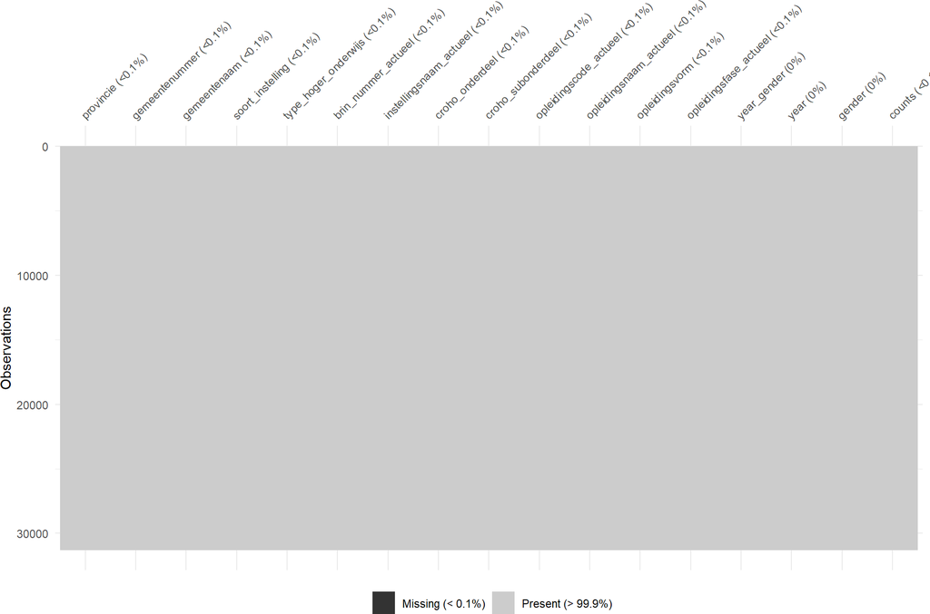

```r
vis_miss(data_tidy)
```

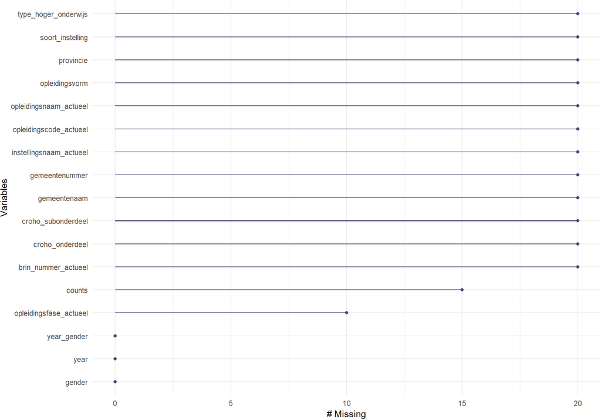

```r
naniar::gg_miss_var(data_tidy)
```

```r
data_tidy <- na.omit(data_tidy)
```

# 3 Exploratory Data Analysis

## 3.1 Distributions

- Many zero or low counts
- The median is 24

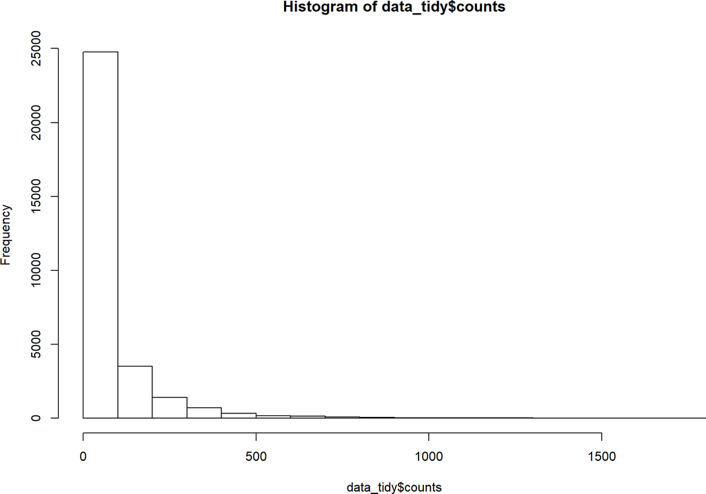

```r
median <- median(data_tidy$counts, na.rm = TRUE) %>% log10()
hist(data_tidy$counts)
```

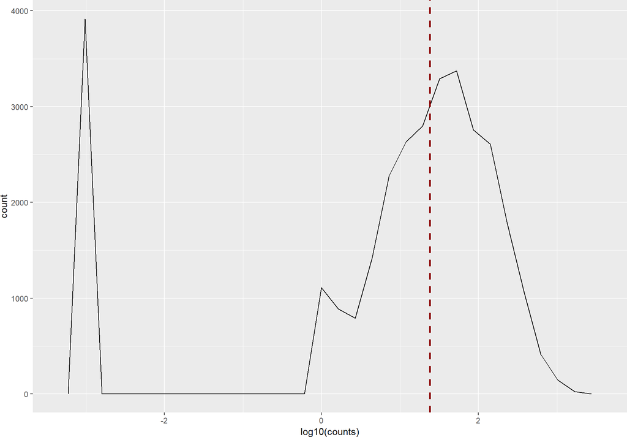

```r
data_tidy %>%
  mutate(counts = counts + 0.001) %>% ## add a pseudocount of 0.001 for log10 transform
  ggplot(aes(x = log10(counts))) +
  geom_freqpoly() +
  geom_vline(xintercept = median, colour = "darkred", linetype = "dashed", size = 1)
```

## 3.2 Ditrubutions per chroho

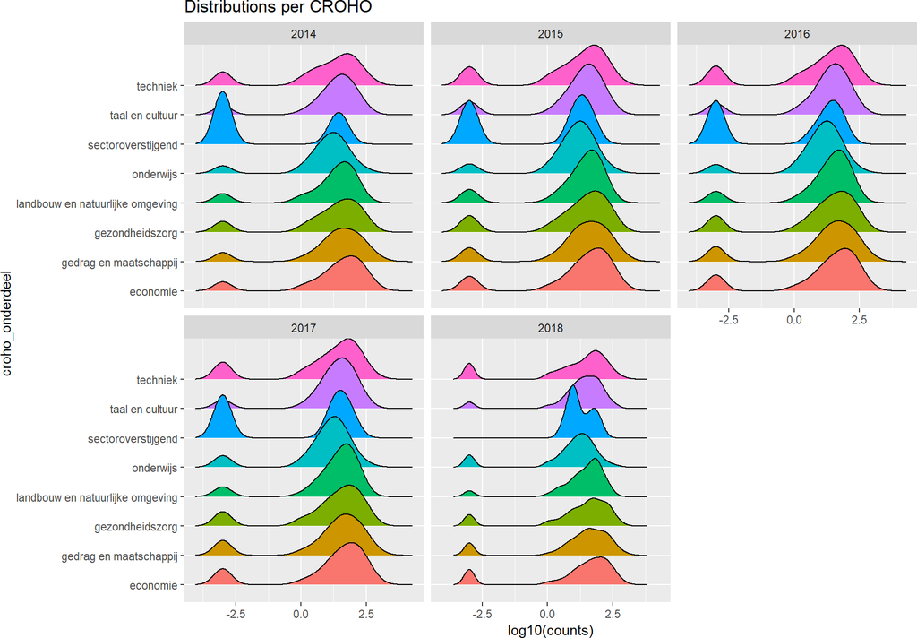

```r
data_tidy %>%
   mutate(counts = counts + 0.001) %>% ## add a pseudocount of 0.001 for log10 transform
  na.omit() %>%
  ggplot(
    aes(x = log10(counts),
    y = croho_onderdeel,
    fill = croho_onderdeel)) +
      geom_density_ridges() +
      theme(legend.position = "none")+
      labs(title = "Distributions per CROHO") +
  facet_wrap(~ year)
```

## 3.3 All crohos over time

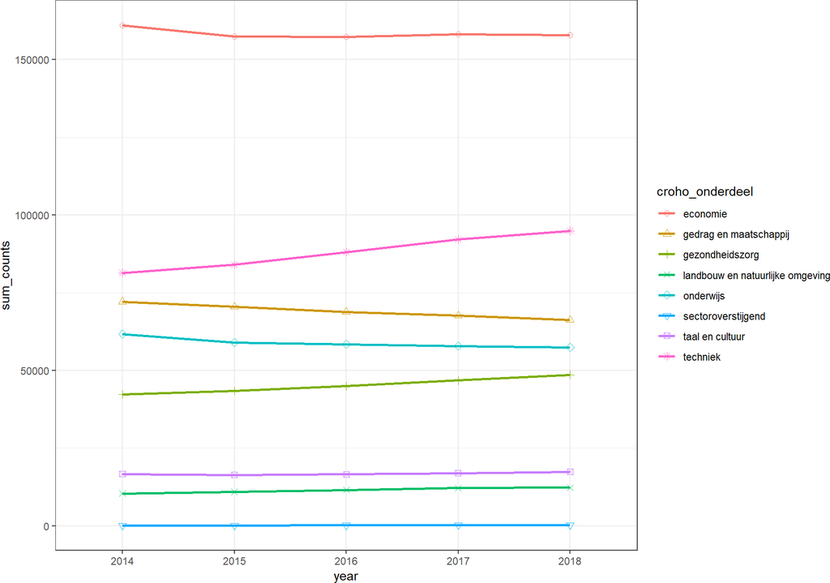

```r
data_tidy %>%
#  dplyr::filter(counts < 10) %>%
  group_by(year, croho_onderdeel) %>%
  summarise(sum_counts = sum(counts)) %>%
  ggplot(aes(x = year, y = sum_counts)) +
  geom_point(aes(colour = croho_onderdeel,
                 shape = croho_onderdeel), size = 2) +
  geom_line(aes(colour = croho_onderdeel,
                group = croho_onderdeel), size = 1) +
  scale_shape_manual(values = c(1:8)) +
  theme_bw()
```

## 3.4 General pattern over time for all institutes, cummulative

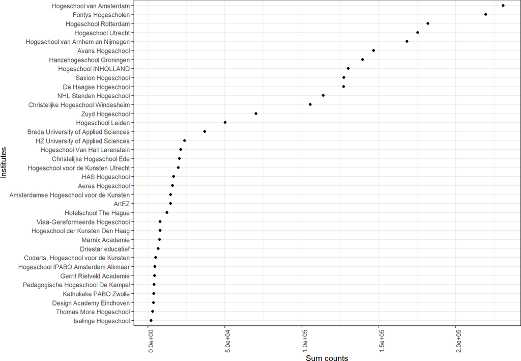

```r
library(toolboxr)
data_tidy %>%
  group_by(instellingsnaam_actueel) %>%
  summarise(sum_counts = sum(counts)) %>%
  ggplot(aes(x = sum_counts,
             y = reorder(
               as_factor(instellingsnaam_actueel), sum_counts
               ))) +
  geom_point() +
  theme_bw() +
#  facet_wrap(~year, nrow = 1) +
  ylab("Institutes") +
  xlab("Sum counts") +
  rotate_axis_labels(axis = "x", angle = 90) +
  scale_x_continuous(labels = scales::scientific)
```

## 3.5 General pattern over time for all institutes, over the years

Here we examine the registered students on the global institutional level. All enrollments are summed per institute and year to get a general overview.

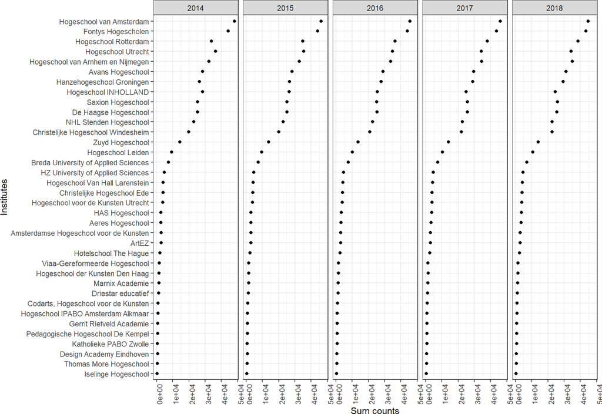

```r
library(toolboxr)
data_tidy %>%
  group_by(year, instellingsnaam_actueel) %>%
  summarise(sum_counts = sum(counts)) %>%
  ggplot(aes(x = sum_counts,
             y = reorder(
               as_factor(instellingsnaam_actueel), sum_counts
               ))) +
  geom_point() +
  theme_bw() +
  facet_wrap(~year, nrow = 1) +
  ylab("Institutes") +
  xlab("Sum counts") +
  rotate_axis_labels(axis = "x", angle = 90) +
  scale_x_continuous(labels = scales::scientific)
```

# 4 Parameterized report

To zoom in on one institute, the remainder of this report is paramterized for one institute, croho or education track

## 4.1 Generic pattern for education tracks within one croho, only the larger educational tracks (> 3000 total enrollments, in each year)

```r
library(directlabels)
library(ggrepel)
```

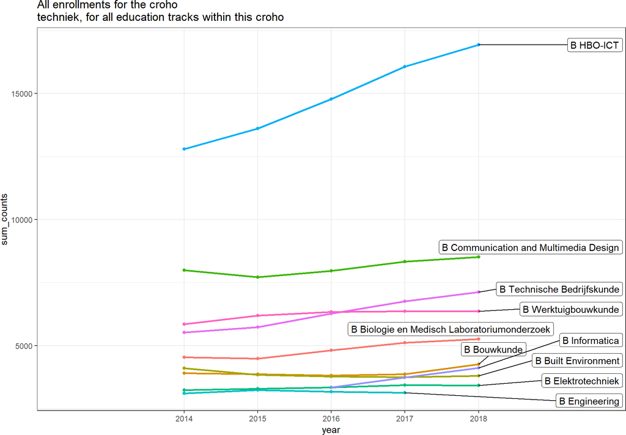

```r
data_tidy %>%
  dplyr::filter(croho_onderdeel == params$croho) %>%
  group_by(opleidingsnaam_actueel, year) %>%

  summarise(sum_counts = sum(counts)) %>%
  filter(sum_counts > 3000) %>%
  mutate(label = if_else(year == max(year),
                         as.character(
                           opleidingsnaam_actueel),
                         NA_character_)) %>%


    ggplot(aes(x = year, y = sum_counts)) +
  geom_point(aes(colour = opleidingsnaam_actueel), size = 1.5) +
  geom_line(aes(colour = opleidingsnaam_actueel,
                group = opleidingsnaam_actueel), size = 1) +
  theme_bw() +
  theme(legend.position = "none") +
  ggtitle(paste("All enrollments for the croho \n",
                params$croho, ", for all education tracks within this croho", sep = "")) +

  scale_x_discrete(expand=c(0, 2)) +
  geom_label_repel(aes(label = label),
                  nudge_x = 3,
                  nudge_y = 2,
                  na.rm = TRUE)
```

```r
data_tidy %>%
  dplyr::filter(croho_onderdeel == params$croho) %>%
  group_by(opleidingsnaam_actueel, year) %>%

  summarise(sum_counts = sum(counts)) -> highest

high_track <- highest %>%
  filter(sum_counts == max(highest$sum_counts))
```

## 4.2 Educational with maximum enrollment in croho techniek track B HBO-ICT at a closer look

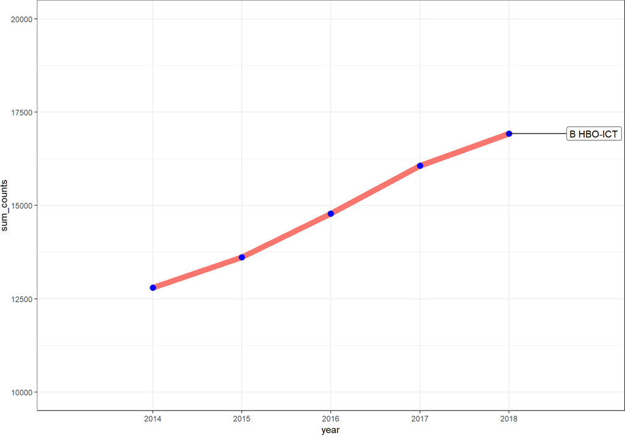

```r
data_tidy %>%
  dplyr::filter(croho_onderdeel == params$croho) %>%
  group_by(opleidingsnaam_actueel, year) %>%
  summarise(sum_counts = sum(counts)) %>%

  mutate(label = if_else(year == max(year),
                         as.character(
                           opleidingsnaam_actueel),
                         NA_character_)) %>%

  dplyr::filter(opleidingsnaam_actueel %in% high_track$opleidingsnaam_actueel) %>%
  ggplot(aes(x = year, y = sum_counts)) +
  geom_line(aes(colour = opleidingsnaam_actueel,
                group = opleidingsnaam_actueel), size = 3) +

  geom_point(size = 3, colour = "blue") +
  theme_bw() +
  theme(legend.position = "none") +

  scale_x_discrete(expand=c(0, 1.3)) +
  ylim(c(10000, 20000)) +
  geom_label_repel(aes(label = label),
                  nudge_x = 3,
                  nudge_y = 2,
                  na.rm = TRUE)
```

## 4.3 Generic pattern for B Biologie en Medisch Laboratoriumonderzoek

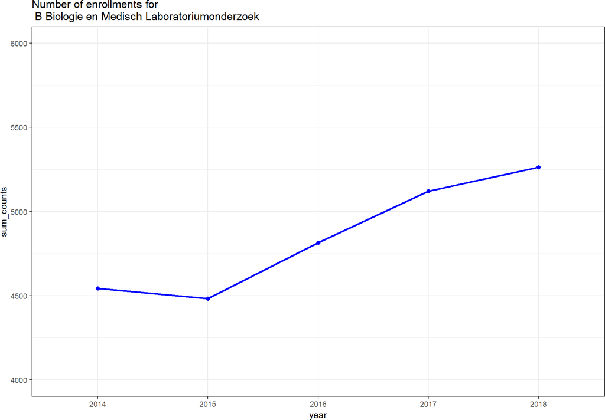

```r
data_tidy %>%
  dplyr::filter(opleidingsnaam_actueel == params$education_track) %>%
  group_by(opleidingsnaam_actueel, year) %>%
  summarise(sum_counts = sum(counts)) %>%
  ggplot(aes(x = year, y = sum_counts)) +
  geom_point(aes(colour = opleidingsnaam_actueel), size = 2, colour = "blue") +
  geom_line(aes(colour = opleidingsnaam_actueel,
                group = opleidingsnaam_actueel), size = 1,
            colour = "blue") +
  theme_bw() +
  theme(legend.position = "none") +
  ggtitle(paste("Number of enrollments for \n",
                params$education_track)) +
  ylim(4000, 6000)
```

### 4.3.1 Generic pattern for B Biologie en Medisch Laboratoriumonderzoek over institutes providing this track.

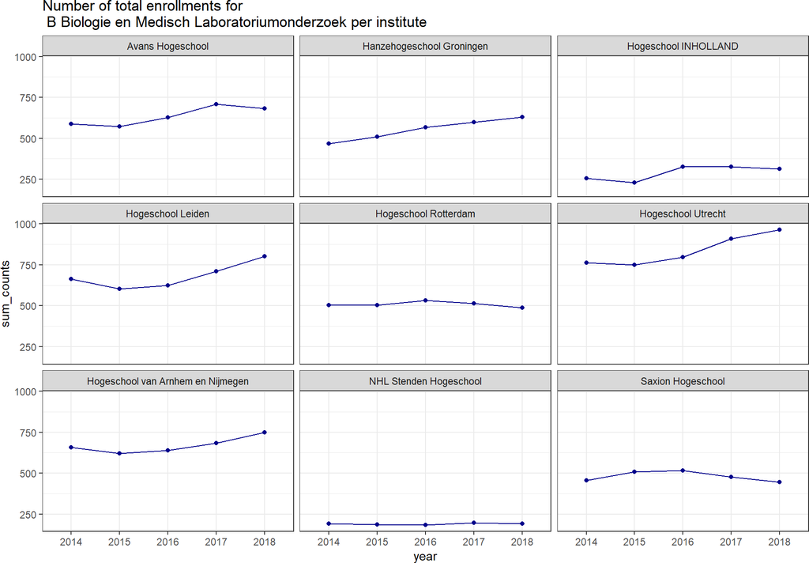

```r
data_tidy %>%
  dplyr::filter(opleidingsnaam_actueel == params$education_track) %>%
  group_by(opleidingsnaam_actueel, year, instellingsnaam_actueel) %>%
  summarise(sum_counts = sum(counts)) %>%
  ggplot(aes(x = year, y = sum_counts)) +
  geom_point(aes(colour = opleidingsnaam_actueel),
             colour = "darkblue") +
  geom_line(aes(colour = opleidingsnaam_actueel,
                group = opleidingsnaam_actueel),
            colour = "darkblue") +
  theme_bw() +
  theme(legend.position = "none") +
  ggtitle(paste("Number of total enrollments for \n",
                params$education_track, "per institute")) +
  facet_wrap(~ instellingsnaam_actueel)
```

# 5 Gender differences

## 5.1 For croho techniek

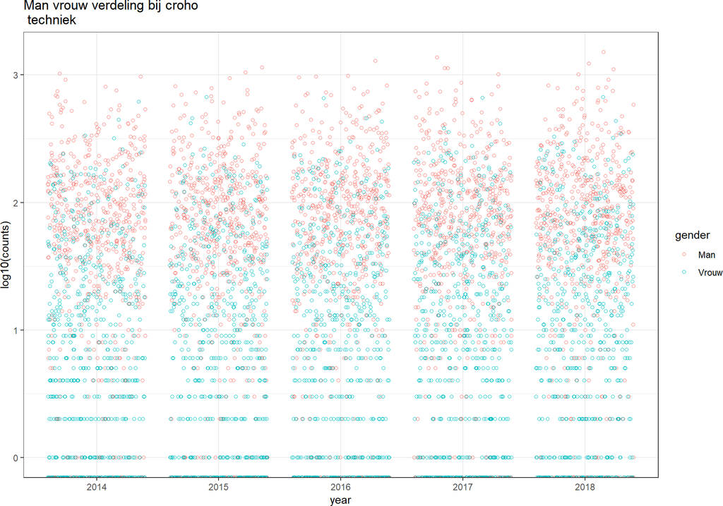

```r
data_tidy %>%
  dplyr::filter(croho_onderdeel == params$croho) %>%
#  mutate(counts_log2 = log2(counts + 0.0001)) %>%
#  dplyr::filter(counts_log2 > 2.5) %>%
  ggplot(aes(x = year,
             y = log10(counts))) +
  geom_point(aes(colour = gender),
             shape = 1, position = "jitter") +
  geom_smooth(method = "lm") +

  ggtitle(paste("Man vrouw verdeling bij croho \n",
                params$croho)) +
  theme_bw()
```

## 5.2 For educational track B Biologie en Medisch Laboratoriumonderzoek

Male female distributions

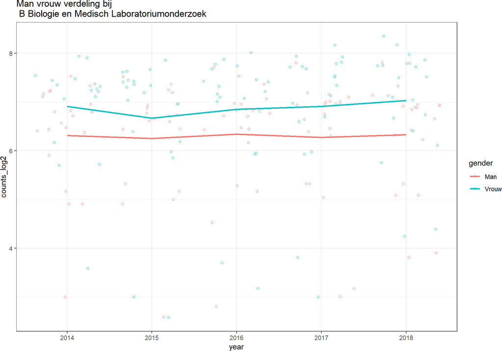

```r
data_tidy %>%
  dplyr::filter(
    opleidingsnaam_actueel == params$education_track) %>%
  mutate(counts_log2 = log2(counts + 0.0001)) %>%
  dplyr::filter(counts_log2 > 2.5) %>%
  ggplot(aes(x = year,
             y = counts_log2)) +
  geom_point(aes(colour = gender),
             shape = 1, position = "jitter") +
  geom_smooth(aes(group = gender, colour = gender), method = "loess", se = FALSE) +
  ggtitle(paste("Man vrouw verdeling bij \n",
                params$education_track)) +
  theme_bw()
```

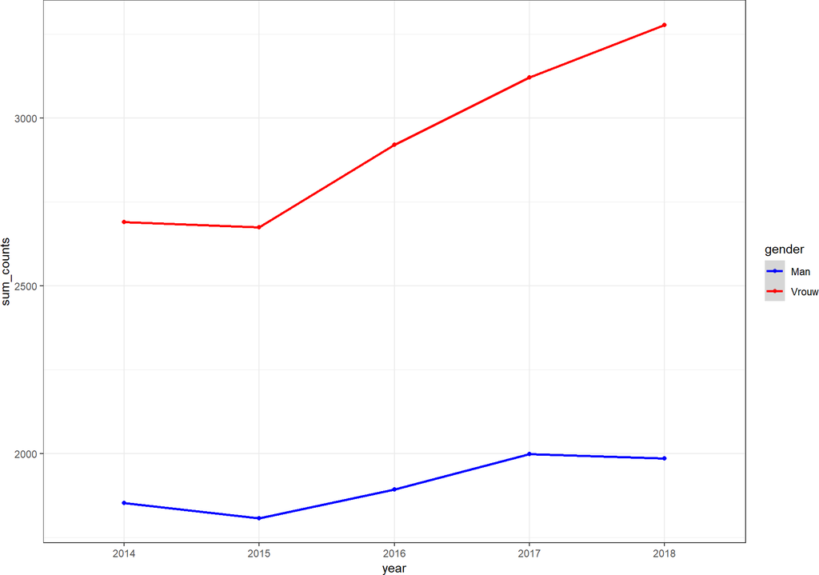

```r
data_tidy %>%
  dplyr::filter(
    opleidingsnaam_actueel == params$education_track) %>%
#  mutate(counts_log2 = log2(counts + 0.0001)) %>%
  group_by(gender, year) %>%
  summarise(sum_counts = sum(counts)) %>%
#  dplyr::filter(counts_log2 > 2.5) %>%
  ggplot(aes(x = year,
             y = sum_counts)) +
  geom_point(aes(colour = gender)) +
  geom_smooth(aes(group = gender, colour = gender)) +
#  geom_smooth(aes(group = gender, colour = gender), method = "loess", se = FALSE) +
  scale_color_manual(values = c("blue", "red")) +
  theme_bw()
```